# Math 564 Project

# Q-Q Residuals:

# Scale-Location:

# Residuals vs Leverage:

# Histogram of Residuals:

## Multicollinearity:

```r
# Calculate VIF for each predictor
vif_values <- vif(model)
print(vif_values)
```

```
##                  Item_Weight             Item_Fat_Content
##                     1.003746                     1.013793
##              Item_Visibility                     Item_MRP
##                     1.094109                     4.160404
##                  Outlet_Size      Item_Identifier_Encoded
##                     3.238495                     4.189129
##            Item_Type_Encoded    Outlet_Identifier_Encoded
##                     1.023269                   230.351348
## Outlet_TypeSupermarket_Type1 Outlet_TypeSupermarket_Type2
##                   305.421060                    88.687240
## Outlet_TypeSupermarket_Type3   Outlet_Location_TypeTier_2
##                   361.595339                     1.630302
##   Outlet_Location_TypeTier_3
##                     6.045131
```

The Variance Inflation Factor (VIF) values help assess multicollinearity in the model, where a VIF above 10 often indicates high multicollinearity. Here’s an interpretation of the VIF results:

# Low VIF (1–4 range): These predictors show minimal multicollinearity.

Item_Weight (1.00), Item_Fat_Content (1.01), Item_Visibility (1.09), Item_Type_Encoded (1.02): Very low VIF, indicating negligible multicollinearity. Outlet_Location_TypeTier_2 (1.63): Low multicollinearity, Outlet_Size (3.24): Moderate multicollinearity, but acceptable.

# Moderate VIF (4–6):

Item_MRP (4.16), Item_Identifier_Encoded (4.19): Moderate multicollinearity, but generally acceptable. Outlet_Location_TypeTier_3 (6.05): Slightly higher but still manageable multicollinearity.

#High VIF (10+): These predictors indicate strong multicollinearity and may be redundant in the model.

Outlet_Identifier_Encoded (230.35): Very high VIF, indicating significant collinearity. Outlet_TypeSupermarket_Type1 (305.42), Outlet_TypeSupermarket_Type2 (88.69), Outlet_TypeSupermarket_Type3 (361.60): Extremely high VIFs suggest these outlet types are highly collinear with each other or other variables.

## Influential Points:

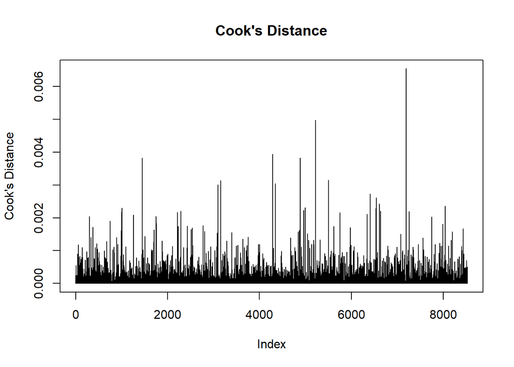

```r
# Cook's Distance plot
cooksD <- cooks.distance(model)
plot(cooks.distance(model), type = "h", main = "Cook's Distance", ylab = "Cook's Distance")
```

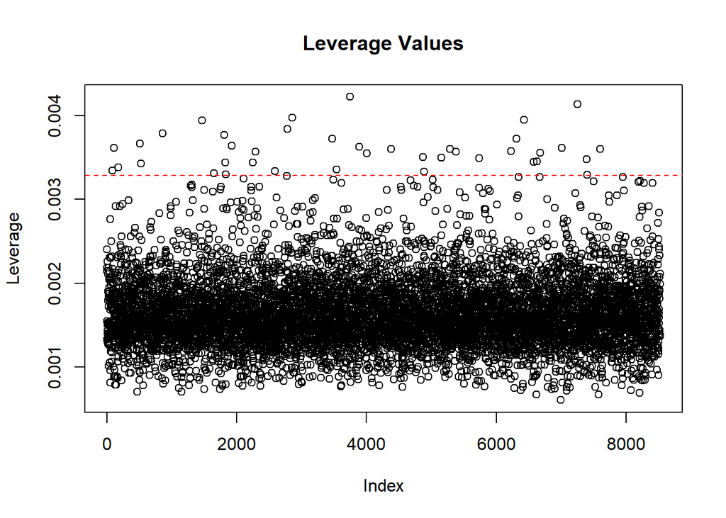

```r
#finding influential points using cooks distance:
threshold <- 4/nrow(data)
influential_points <- which(cooksD > threshold)
#print(influential_points)
# Leverage values
leverage_values <- hatvalues(model)

# Plot leverage values to check for high leverage points
plot(leverage_values, main = "Leverage Values", ylab = "Leverage")
abline(h = 2 * mean(leverage_values), col = "red", lty = 2)
```

# Cooks Distance:

Points with a Cook’s Distance value significantly higher than the average or greater than 1 are usually flagged as influential. In this plot, most data points have very low Cook’s Distance values, suggesting they are not highly influential.

# Leverage Values:

Leverage Threshold: Typically, a rule of thumb is to consider points with leverage values significantly higher than (2p/n) where p is the number of predictors and n is the number of observations. Observations above this threshold are often flagged as having high leverage. In this plot, Points above the red dashed line (around 0.003) are considered high-leverage points but cooks distance suggest they are not Influential Points.

# Describe how each diagnostic affects the interpretation of your regression model.

From the regression diagnostics conducted on the model, we identified two major issues: a.High VIFs, which indicate multicollinearity among predictors. This affects model interpretation in the following ways:

1. Unstable Coefficients High multicollinearity makes coefficients sensitive to minor data changes, causing instability in the direction and size of relationships, which reduces confidence in interpreting individual predictors.
2. Difficulty in Isolating Effects With high VIFs, it’s hard to determine each predictor’s unique contribution. For example, if Outlet_Identifier_Encoded and Outlet_Type categories are highly collinear, their effects overlap, reducing clarity about their individual impact on Item_Outlet_Sales.
2. Heteroscedasticity

We will address this issue by removing Outlet_TypeSupermarket_Type1, Outlet_TypeSupermarket_Type2, and Outlet_TypeSupermarket_Type3 since these are highly collinear predictors. We have not removed the Outlet_Identifier_Encoded since its p-score has proven the feature is significant.

## 4 Remediation (Part III): Addressing Model Issues

```r
# In order to control the effect of heteroscedasticity we are applying log transformation to the dependent variable
data$Log_Item_Outlet_Sales <- log(data$Item_Outlet_Sales)

# Fit the linear model with the log-transformed dependent variable and
# removed Outlet_TypeSupermarket_Type1, Outlet_TypeSupermarket_Type2, and Outlet_TypeSupermarket_Type3
model <- lm(Log_Item_Outlet_Sales ~ Item_Weight + Item_Fat_Content + Item_Visibility + Item_MRP +
              Outlet_Size + Item_Identifier_Encoded + Item_Type_Encoded + Outlet_Identifier_Encoded +
              Outlet_Location_TypeTier_2 + Outlet_Location_TypeTier_3,
            data = data)
# Summarize the new model
summary(model)
```

```
##
## Call:
## lm(formula = Log_Item_Outlet_Sales ~ Item_Weight + Item_Fat_Content +
##     Item_Visibility + Item_MRP + Outlet_Size + Item_Identifier_Encoded +
##     Item_Type_Encoded + Outlet_Identifier_Encoded + Outlet_Location_TypeTier_2 +
##     Outlet_Location_TypeTier_3, data = data)
##
## Residuals:
##      Min       1Q   Median       3Q      Max
## -2.21879 -0.30718  0.05416  0.38214  1.48965
##
## Coefficients:
##                              Estimate Std. Error t value Pr(>|t|)
## (Intercept)                 4.464e+00  1.123e-01  39.746  < 2e-16 ***
## Item_Weight                -4.740e-04  1.385e-03  -0.342  0.73217
## Item_Fat_Content            3.220e-03  1.231e-02   0.262  0.79371
## Item_Visibility            -4.654e-01  1.174e-01  -3.965 7.39e-05 ***
## Item_MRP                    3.539e-03  1.914e-04  18.493  < 2e-16 ***
## Outlet_Size                 1.557e-01  1.260e-02  12.358  < 2e-16 ***
## Item_Identifier_Encoded     3.089e-04  1.072e-05  28.809  < 2e-16 ***
## Item_Type_Encoded          -5.175e-05  5.031e-05  -1.029  0.30372
## Outlet_Identifier_Encoded   7.382e-04  7.489e-06  98.576  < 2e-16 ***
## Outlet_Location_TypeTier_2  4.186e-02  1.570e-02   2.666  0.00769 **
## Outlet_Location_TypeTier_3 -2.646e-01  1.832e-02 -14.439  < 2e-16 ***
## ---
## Signif. codes:  0 '***' 0.001 '**' 0.01 '*' 0.05 '.' 0.1 ' ' 1
##
## Residual standard error: 0.5394 on 8512 degrees of freedom
## Multiple R-squared:  0.7191, Adjusted R-squared:  0.7188
## F-statistic:  2179 on 10 and 8512 DF,  p-value: < 2.2e-16
```

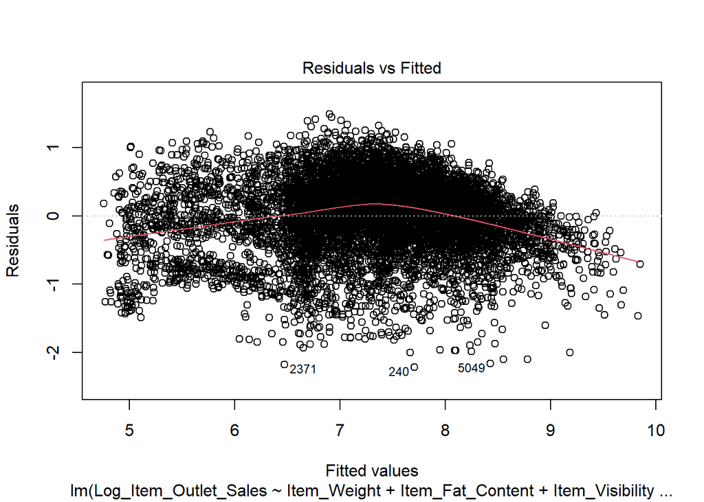

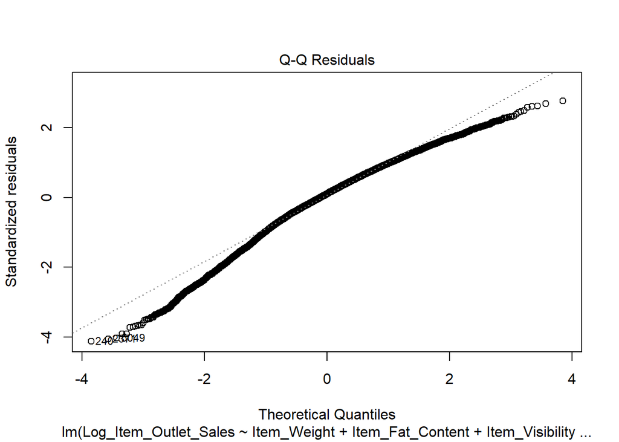

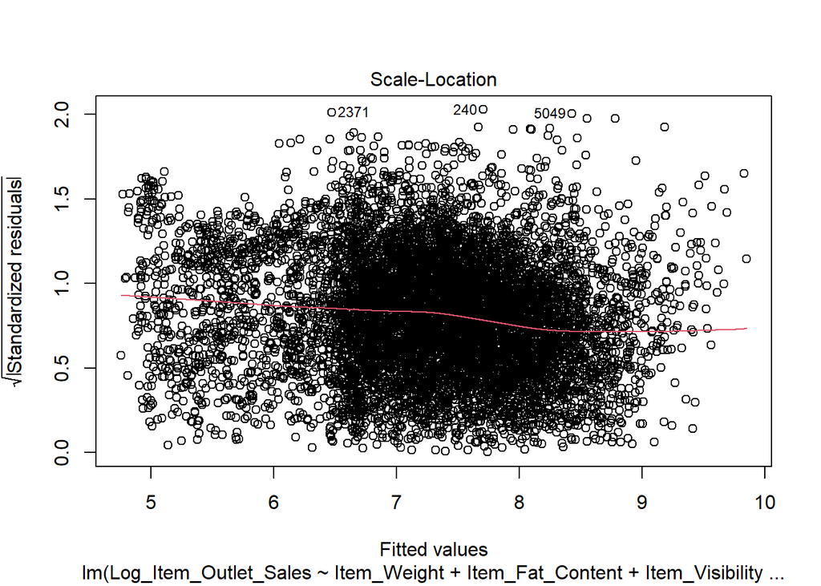

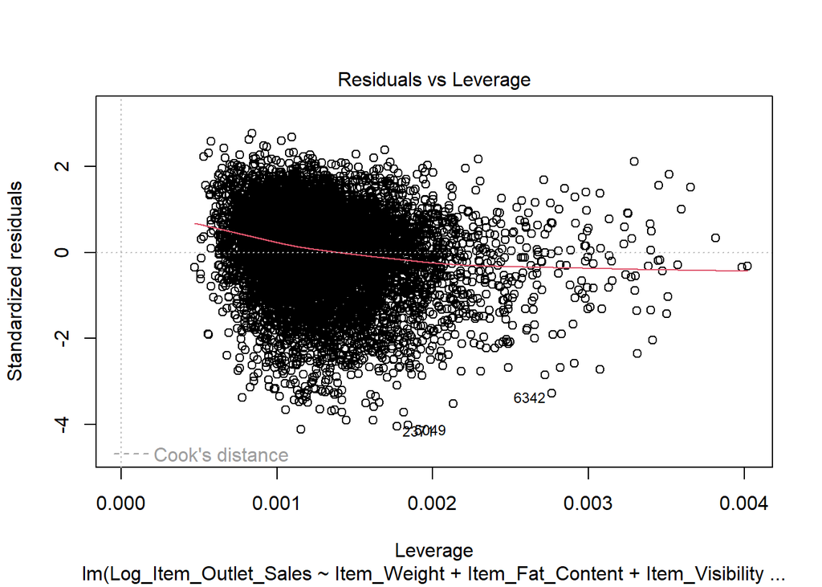

```r
# Check residuals to assess if heteroscedasticity has been reduced
#par(mfrow = c(2, 2))  # Set up plot layout
plot(model)  # Diagnostic plots to evaluate model fit and residuals
```

```r
model <- lm(Log_Item_Outlet_Sales ~ Item_Visibility + Item_MRP +
              Outlet_Size + Item_Identifier_Encoded + Outlet_Identifier_Encoded +
              Outlet_Location_TypeTier_2 + Outlet_Location_TypeTier_3,
            data = data)

summary(model)
```

```
##
## Call:
## lm(formula = Log_Item_Outlet_Sales ~ Item_Visibility + Item_MRP +
##     Outlet_Size + Item_Identifier_Encoded + Outlet_Identifier_Encoded +
##     Outlet_Location_TypeTier_2 + Outlet_Location_TypeTier_3,
##     data = data)
##
## Residuals:
##      Min       1Q   Median       3Q      Max
## -2.21163 -0.30690  0.05439  0.38257  1.48772
##
## Coefficients:
##                              Estimate Std. Error t value Pr(>|t|)
## (Intercept)                 4.352e+00  3.002e-02 144.954  < 2e-16 ***
## Item_Visibility            -4.670e-01  1.172e-01  -3.986 6.77e-05 ***
## Item_MRP                    3.531e-03  1.911e-04  18.478  < 2e-16 ***
## Outlet_Size                 1.557e-01  1.260e-02  12.356  < 2e-16 ***
## Item_Identifier_Encoded     3.087e-04  1.070e-05  28.838  < 2e-16 ***
## Outlet_Identifier_Encoded   7.381e-04  7.487e-06  98.587  < 2e-16 ***
## Outlet_Location_TypeTier_2  4.183e-02  1.570e-02   2.665  0.00771 **
## Outlet_Location_TypeTier_3 -2.646e-01  1.832e-02 -14.443  < 2e-16 ***
## ---
## Signif. codes:  0 '***' 0.001 '**' 0.01 '*' 0.05 '.' 0.1 ' ' 1
##
## Residual standard error: 0.5393 on 8515 degrees of freedom
## Multiple R-squared:  0.719,  Adjusted R-squared:  0.7188
## F-statistic:  3113 on 7 and 8515 DF,  p-value: < 2.2e-16
```

```r
# Calculating VIF for each predictor after high collinear feature removal:
vif_values <- vif(model)
print(vif_values)
```

```
##            Item_Visibility                   Item_MRP
##                   1.070597                   4.150049
##                Outlet_Size    Item_Identifier_Encoded
##                   1.676013                   4.175389
##  Outlet_Identifier_Encoded Outlet_Location_TypeTier_2
##                   1.151786                   1.588250
## Outlet_Location_TypeTier_3
##                   2.346606
```

Well now we can clearly observe none of the VIF values are above 4.2 which suggests we have clearly reduced the impact of collinearity in the model, suggesting the removed features successfully reduced redundancy.